# Handling player input

In this lesson, we’ll let the player control unit movement.

With one or more units selected, the player should be able to right-click a cell to issue a move command.

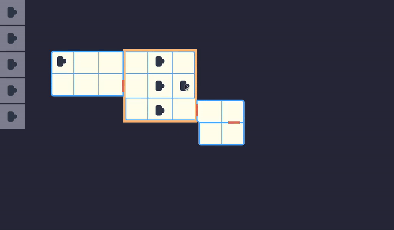

We’re going to keep working on `ShipTemplate.gd` to handle the player’s mouse input.

We can view this as a pattern in Godot where we use a parent node to handle some functionality that depends on children.

Instead of coding this into some deeply nested child node and have signals in and out all over the place, it’s simplest to move the functionality into the parent node that can reference any child.

Before we work on the `ShipTemplate` script, we need a new function in `Utils.gd`. Open the script and define `erase_value()`. We’ll use it to update a unit’s position on the ship’s grid.

```
## Finds and erases all keys corresponding to the given `value` in the dictionary.
## `value` is left without type hint intentionally: it's so the function works with
## all types, including vectors, references, etc.
static func erase_value(dict: Dictionary, value) -> bool:
    var out := false
    for key in dict:
        if dict[key] == value:
            out = dict.erase(key)
    return out
```

In `ShipTemplate.gd`, we start by creating a dictionary that’ll keep track of each unit’s location. We use cell coordinates as keys and a reference to the corresponding unit as its value.

GDScript dictionaries support that, which is more convenient than using arrays and offers good performance.

```
## This dictionary will keep track of unit locations, but also hazards like
## fire in some cells.
var _slots := {}

#...
func _ready_not_editor_hint() -> void:
    for unit in units.get_children():
        # We calculate the cell coordinates of each unit and store the unit in
        # the dictionary.
        var position_map := tilemap.world_to_map(unit.path_follow.position)
        _slots[position_map] = unit

    # for room in rooms.get_children():
    # ...
```

With this dictionary populated, we can handle player interaction:

```
func _unhandled_input(event: InputEvent) -> void:
    # Units should move only when right-clicking, so we return from the
    # function on any other input.
    if not event.is_action_pressed("right_click"):
        return

    # If the player right-clicked, we get all selected units and make them move to the selected room.
    for unit in get_tree().get_nodes_in_group("selected-unit"):
        # Below, point1 and point2 are respectively the unit's position and an empty slot the room will find for us.
        var point1: Vector2 = tilemap.world_to_map(unit.path_follow.position)
        for room in get_tree().get_nodes_in_group("selected-room"):
            # We have yet to define `Room.get_slot()`, we'll do it later in the lesson.
            var point2: Vector2 = room.get_slot(_slots, unit)
            # If the location isn't valid we break out of the loop.
            # `Room.get_slot()` will return infinity values so we can reliably check for an invalid slot.
            # The location can be invalid if the room is already full, in which case we don't want to move more units there.
            if is_inf(point2.x):
                break

            # If the location is valid, we pathfind from the current to the target slot.
            var path: Curve2D = tilemap.find_path(point1, point2)
            # We update the dictionary tracking where units are.
            # We need to use `erase_value()` here because of how units will
            # slowly walk to their target.
            # It's a reliable way to remove the correct keys from the dictionary.
            Utils.erase_value(_slots, unit)
            _slots[point2] = unit
            unit.walk(path)
```

*Note* that we use `_unhandled_input()` this time. We want the UI to block any user interaction before we get to the game world.

Now, we temporarily have a “broken” game and we need to fill in the missing functionality: `Unit.walk()` and `Room.get_slot()`.

### Making units walk

Let’s start with `Unit.gd` and make the units walk along the path. Open the script and add the following variables at the top:

```
# The speed at which the unit walks along the path in pixels per second.
export var speed := 150

# If true, the unit should walk along the path until it reaches the end.
var is_walking: bool setget set_is_walking

onready var path_follow: PathFollow2D = $PathFollow2D

func _ready() -> void:
    # area_unit.modulate = COLORS.default

    # By default, we want the units to start as stationary:
    # We use `self` to trigger a call to the `set_is_walking()` setter function.
    self.is_walking = false


func set_is_walking(value: bool) -> void:
    is_walking = value
    set_process(is_walking)
```

We use the fact that all Godot nodes have a `_process()` function, which we can turn on or off with `set_process()`.

Instead of worrying about forgetting to add `set_process()` to the relevant places, we use the setter function instead. Now let’s see what `_process()` actually does:

```
func _process(delta: float) -> void:
    # We move along the path based on the unit's `speed`.
    # Updating the `PathFollow2D` node's `offset` automatically moves its children
    # along the curve.
    path_follow.offset += speed * delta
    # `curve` is a property of `Path2D` which gives us our path's length.
    # If the offset gets greater than the path's length, we reached the end
    # and stop walking.
    if path_follow.offset >= curve.get_baked_length():
        self.is_walking = false
```

Now we have the movement code, we can go over `walk()`, which sets the path to follow:

```
## Assigns the given `Curve2D` `path` to `curve`. It appends `path_follow.position`
## as the starting point on the `curve`.
func walk(path: Curve2D) -> void:
    # This checks the path is valid.
    if path.get_point_count() == 0:
        return

    curve = path
    # As mentioned in the previous lesson, our `TileMap.find_path()` method
    # returns the path missing the start position. That's because we want the
    # current unit position instead to take into account already moving units.
    #
    # Note that the two `Vector2.ZERO` parameters are the in and out bezier
    # curve handles. They're an offset from the curve's position.
    # You can use them to curve the path.
    # We don't want any curves so we set them `Vector2.ZERO`.
    curve.add_point(path_follow.position, Vector2.ZERO, Vector2.ZERO, 0)
    # We place the unit at the start of the path and make it walk.
    path_follow.offset = 0
    self.is_walking = true
```

### Keeping track of available room slots

With `Unit.gd` taken care of, let’s focus on the missing functionality from `Room.gd`.

In `ShipTemplate.gd` we added a call to `room.get_slot()` to find a non-occupied tile in the destination room.

The thing is, sometimes rooms can connect with neighboring rooms by more than one door. We need to take this into account when calculating the path.

To find a slot for each unit to walk to, we will:

- Find the door closest to the unit. That’s the door the unit will move through.
- List all the available slots in the room.
- Sort the slots from closest to farthest from the door.
- Return the closest slot.

Let’s start by getting a list of all entrances in a room. Open `Room.gd` and add the following code.

```
# ...
# var _iter_index := 0

## Keeps track of tiles next to doors.
##
## The reason we use a dictionary instead of an array is because it's much
## faster to check for keys in a dictionary than for elements in an array.
var _entrances := {}
```

At the start of the game, we want to initialize `_entrances` based on the door placement. We can do this efficiently with the `area_entered` signal instead of looping over all doors every time.

There’s one challenge here: finding the cell next to a door in each room.

To do so:

1. We get a vector going from the door to the center of the room.
2. We project the vector onto the door’s normal (vector perpendicular to the door) and turn it into a direction. This gives us the direction of the cell inside the room.
3. From that direction, we calculate an offset to find the cell’s center.

```
func _ready() -> void:
    # ...
    # connect("mouse_exited", self, "_on_mouse_entered_exited", [false])
    # The room's area automatically detects doors touching the room.
    connect("area_entered", self, "_on_area_entered")


func _on_area_entered(area: Area2D) -> void:
    if area.is_in_group("door"):
        # Here, we find the coordinates of the room tile next to the door.
        # First, we get the vector pointing from the door to the middle of the
        # room.
        var entrance := position - area.position
        # We project that onto the door normal so it's either vertical or
        # horizontal and points towards the room.
        entrance = entrance.project(Vector2.DOWN.rotated(area.rotation)).normalized()
        # We multiply by half the cell size to get an offset towards the cell's
        # center.
        entrance *= 0.5 * _tilemap.cell_size.x
        # We add the door position to calculate the tile's position on the
        # tilemap.
        entrance += area.position
        # As we have a position in pixels, we need to convert it to `TileMap`
        # coordinates to get the cell's coordinates.
        entrance = _tilemap.world_to_map(entrance)
        # Finally, we store the entrance tile position as a key in the
        # `_entrances` dictionary.
        # We only want the door's coordinates here so we don't associate a value
        # to it.
        _entrances[entrance] = null
```

Now what we want to do is to get the closest entrance given a unit position.

In the `_get_entrance()` function below, we start with an infinite distance. We loop over every door in the room and find a path to it.

We compare the length of every path and return the entrance with the shortest path.

```
## Returns the closest entrance from the `from` location.
func _get_entrance(from: Vector2) -> Vector2:
    var out := Vector2.INF
    var distance := INF
    for entrance in _entrances:
        var curve: Curve2D = _tilemap.find_path(from, entrance)
        var length := curve.get_baked_length()
        if distance > length:
            distance = length
            out = entrance
    return out
```

With all that out of the way, we’re ready to code the `get_slot()` function:

```
func get_slot(slots: Dictionary, unit: Unit) -> Vector2:
    var out := Vector2.INF
    var entrance := _get_entrance(_tilemap.world_to_map(unit.path_follow.position))

    var valid_positions := []
    for offset in self:
        valid_positions.push_back([offset, offset.distance_to(entrance)])
    valid_positions.sort_custom(self, "sort_by_second_index")

    for data in valid_positions:
        var offset: Vector2 = data[0]
        if not (offset in slots and slots[offset] != unit):
            out = offset
            break
    return out


static func sort_by_second_index(a: Array, b: Array) -> bool:
    return a[1] < b[1]
```

## Conclusion

By now, you should have a working game world where you can select units and move them around from room-to-room on `RMB` click.

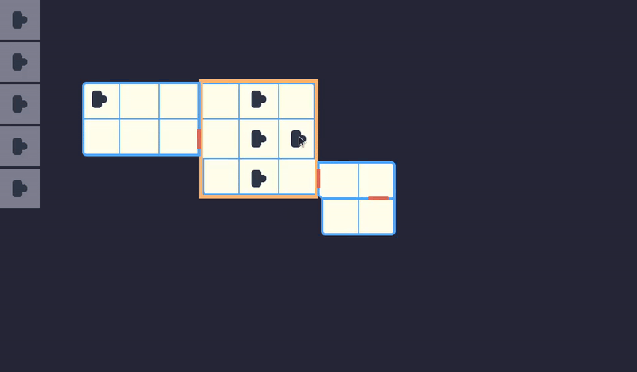

*Note* I instantiated more units in the ship to showcase unit movement.

To view the blue paths that appear in the video, turn on *Debug -> Visible Navigation* from the editor’s menus.

If you play the game now, you’ll notice that the doors don’t interact with the units. We’ll fix this in the next lesson and tie any loose ends before adding the AI ship to the mix.

## Code reference

`res://TacticalSpaceCombat/Utils.gd`

```
class_name Utils

const DIRECTIONS := [
    Vector2.UP,
    Vector2.RIGHT + Vector2.UP,
    Vector2.RIGHT,
    Vector2.RIGHT + Vector2.DOWN,
    Vector2.DOWN,
    Vector2.LEFT + Vector2.DOWN,
    Vector2.LEFT,
    Vector2.LEFT + Vector2.UP
]

## Converts `offset` coordinates to an integer index.
static func xy_to_index(width: int, offset: Vector2) -> int:
    return int(offset.x + width * offset.y)

## Converts an integer `index` to `Vector2(x, y)` coordinates.
static func index_to_xy(width: int, index: int) -> Vector2:
    return Vector2(index % width, index / width)

static func erase_value(dict: Dictionary, value) -> bool:
    var out := false
    for key in dict:
        if dict[key] == value:
            out = dict.erase(key)
    return out
```

`res://TacticalSpaceCombat/Ship/ShipTemplate.gd`:

```
tool
extends Node2D

onready var tilemap: TileMap = $TileMap
onready var rooms: Node2D = $Rooms
onready var units: Node2D = $Units
onready var doors: Node2D = $Doors

var _slots := {}


func _ready() -> void:
    call("_ready_editor_hint" if Engine.editor_hint else "_ready_not_editor_hint")


func _ready_editor_hint() -> void:
    for room in rooms.get_children():
        room.setup(tilemap)


func _ready_not_editor_hint() -> void:
    for unit in units.get_children():
        var position_map := tilemap.world_to_map(unit.path_follow.position)
        _slots[position_map] = unit

    for room in rooms.get_children():
        room.setup(tilemap)

        for point in room:
            tilemap.set_cellv(point, 0)
    tilemap.setup(rooms, doors)


func _unhandled_input(event: InputEvent) -> void:
    if not event.is_action_pressed("right_click"):
        return

    for unit in get_tree().get_nodes_in_group("selected-unit"):
        var point1: Vector2 = tilemap.world_to_map(unit.path_follow.position)
        for room in get_tree().get_nodes_in_group("selected-room"):
            var point2: Vector2 = room.get_slot(_slots, unit)
            if is_inf(point2.x):
                break

            var path: Curve2D = tilemap.find_path(point1, point2)
            Utils.erase_value(_slots, unit)
            _slots[point2] = unit
            unit.walk(path)
```

`res://TacticalSpaceCombat/Ship/Units/Unit.gd`:

```
class_name Unit
extends Path2D

const COLORS := {"default": Color("323e4f"), "selected": Color("3ca370")}

export var speed := 150

var is_walking: bool setget set_is_walking

onready var area_unit: Area2D = $PathFollow2D/AreaUnit
onready var path_follow: PathFollow2D = $PathFollow2D


func _ready() -> void:
    area_unit.modulate = COLORS.default
    self.is_walking = false


func _process(delta: float) -> void:
    path_follow.offset += speed * delta
    if path_follow.offset >= curve.get_baked_length():
        self.is_walking = false


func walk(path: Curve2D) -> void:
    if path.get_point_count() == 0:
        return

    curve = path
    curve.add_point(path_follow.position, Vector2.ZERO, Vector2.ZERO, 0)
    path_follow.offset = 0
    self.is_walking = true


func set_is_walking(value: bool) -> void:
    is_walking = value
    set_process(is_walking)
```

`res://TacticalSpaceCombat/Ship/Rooms/Room.gd`:

```
tool
class_name Room
extends Area2D

export var size := Vector2.ONE setget set_size

var _area := 0
var _top_left := Vector2.ZERO
var _bottom_right := Vector2.ZERO
var _iter_index := 0
var _entrances := {}

var _tilemap: TileMap = null

onready var collision_shape: CollisionShape2D = $CollisionShape2D
onready var feedback: NinePatchRect = $Feedback


func setup(tilemap: TileMap) -> void:
    _tilemap = tilemap
    _setup_extents()
    _area = size.x * size.y
    _top_left = _tilemap.world_to_map(position - collision_shape.shape.extents)
    _bottom_right = _top_left + size

    feedback.rect_position -= collision_shape.shape.extents
    feedback.rect_size = 2 * collision_shape.shape.extents


func _setup_extents() -> void:
    if _tilemap != null:
        collision_shape.shape.extents = 0.5 * _tilemap.map_to_world(size)


func _ready() -> void:
    connect("mouse_entered", self, "_on_mouse_entered_exited", [true])
    connect("mouse_exited", self, "_on_mouse_entered_exited", [false])
    connect("area_entered", self, "_on_area_entered")


func has_point(point: Vector2) -> bool:
    return Rect2(_top_left, size).has_point(point)


func set_size(value: Vector2) -> void:
    for axis in [Vector2.AXIS_X, Vector2.AXIS_Y]:
        size[axis] = max(1, value[axis])
    _setup_extents()


func get_slot(slots: Dictionary, unit: Unit) -> Vector2:
    var out := Vector2.INF
    var entrance := _get_entrance(_tilemap.world_to_map(unit.path_follow.position))

    var valid_positions := []
    for offset in self:
        valid_positions.push_back([offset, offset.distance_to(entrance)])
    valid_positions.sort_custom(self, "sort_by_second_index")

    for data in valid_positions:
        var offset: Vector2 = data[0]
        if not (offset in slots and slots[offset] != unit):
            out = offset
            break
    return out


static func sort_by_second_index(a: Array, b: Array) -> bool:
    return a[1] < b[1]


func _get_entrance(from: Vector2) -> Vector2:
    var out := Vector2.INF
    var distance := INF
    for entrance in _entrances:
        var curve: Curve2D = _tilemap.find_path(from, entrance)
        var length := curve.get_baked_length()
        if distance > length:
            distance = length
            out = entrance
    return out


func _on_area_entered(area: Area2D) -> void:
    if area.is_in_group("door"):
        var entrance := position - area.position
        entrance = entrance.project(Vector2.DOWN.rotated(area.rotation)).normalized()
        entrance *= 0.5 * _tilemap.cell_size.x
        entrance += area.position
        entrance = _tilemap.world_to_map(entrance)
        _entrances[entrance] = null


func _iter_init(_arg) -> bool:
    _iter_index = 0
    return _iter_is_running()


func _iter_next(_arg) -> bool:
    _iter_index += 1
    return _iter_is_running()


func _iter_get(_arg) -> Vector2:
    var offset := Utils.index_to_xy(size.x, _iter_index)
    return _top_left + offset


func _iter_is_running() -> bool:
    return _iter_index < _area


func _on_mouse_entered_exited(has_entered: bool) -> void:
    feedback.visible = has_entered

    var group := "selected-room"
    if has_entered:
        add_to_group(group)
    elif is_in_group(group):
        remove_from_group(group)
```